# Chapter 5: Data Visualization in R

#### Facets

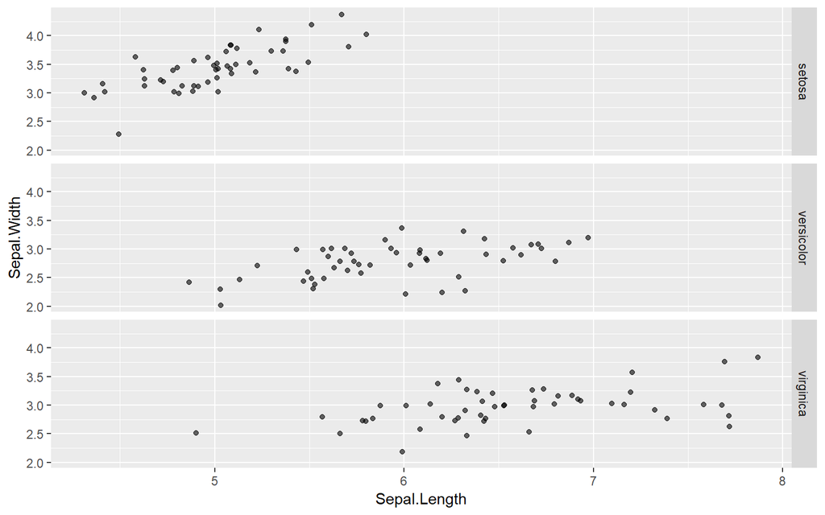

```r
ggplot(iris, aes(x = Sepal.Length, y = Sepal.Width)) +
  geom_jitter(alpha = 0.6) +
  facet_grid(Species ~ .)
```

#### statistics layer

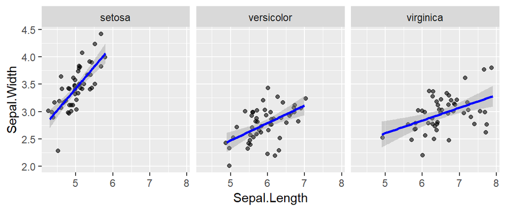

```r
# se = TRUE shows the confidence interval
ggplot(iris, aes(x = Sepal.Length, y = Sepal.Width)) +
  geom_jitter(alpha = 0.6) +
  facet_grid(. ~ Species) +
  stat_smooth(method = "lm", se = TRUE, col = "blue")
```

#### Coordinates layer

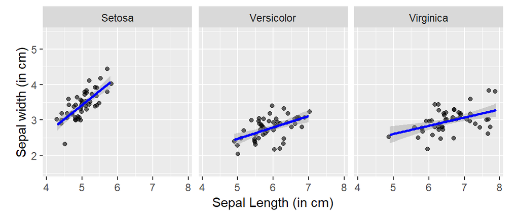

```r
levels(iris$Species) = c("Setosa", "Versicolor", "Virginica")
#   expand is a numeric vector of length two specifies how far the data is placed some distance away from the axes.
ggplot(iris, aes(x = Sepal.Length, y = Sepal.Width)) +
  geom_jitter(alpha = 0.6) +
  facet_grid(. ~ Species) +
  stat_smooth(method = "lm", se = TRUE, col = "blue")+
  scale_y_continuous("Sepal width (in cm)",
                     limits= c(2, 5),
                     expand = c(0, 0.6)) +
  scale_x_continuous("Sepal Length (in cm)",
                     limits = c(4, 8),
                     expand = c(0, 0.1)) +
  coord_equal()
```

#### We can store ggplot2 plot as an object and we can provide aesthetic argument color inside geom_point() layer.

Thus, we can also provide x and y argument in the **geom_point()** layer

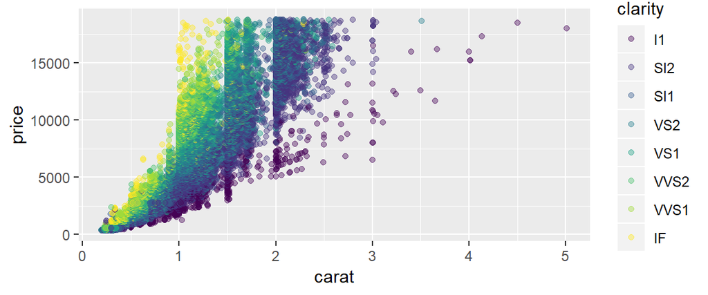

```r
q1 = ggplot(diamonds)
q1 + geom_point(alpha = 0.4, aes(color = clarity, x = carat, y = price))
```

#### Regression fit for each of the species type.

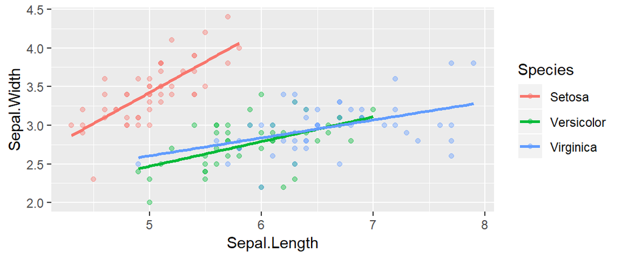

```r
q2 = ggplot(iris, aes(x = Sepal.Length, y = Sepal.Width, color = Species))
q2 = q2 + geom_point(alpha = 0.4)
q2 + geom_smooth(se = FALSE, method = "lm")
```

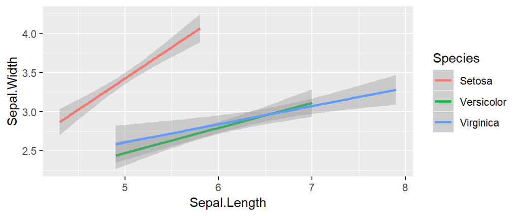

```r
q2_2 = ggplot(iris, aes(x = Sepal.Length, y = Sepal.Width))
q2_2 + geom_smooth(aes(col = Species), method = "lm")
```

Aesthetics in aes() and attributes in geom_(). We can also call aesthetics in geom_(). The latter is done when we have different data sources.

### Common aesthetics used in ggplot2

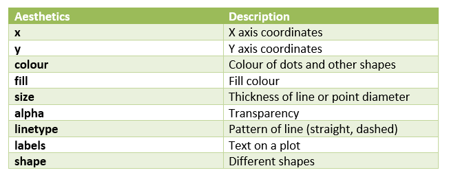

Let’s change the shape and size

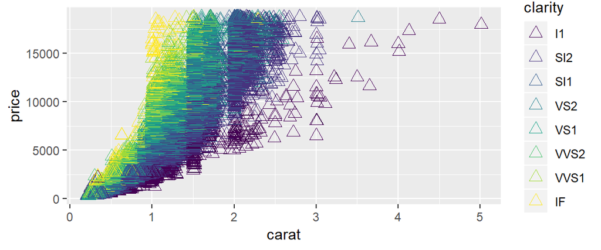

```r
ggplot(diamonds, aes(x = carat, y = price, color = clarity)) +
  geom_point(shape = 2, size = 3)
```

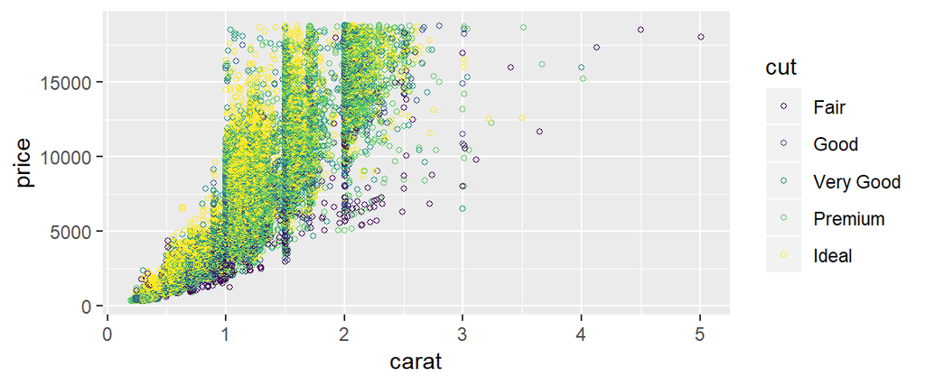

```r
# cut mapped to color
ggplot(diamonds, aes(x = carat, y = price, color = cut)) +
  geom_point(shape = 1, size = 1)
```

Please note that **color** aesthetic changes the outside outline of an object while **fill** aesthetic changes the inside shading.

Below is a graphical representation of all the shapes available in ggplot2.

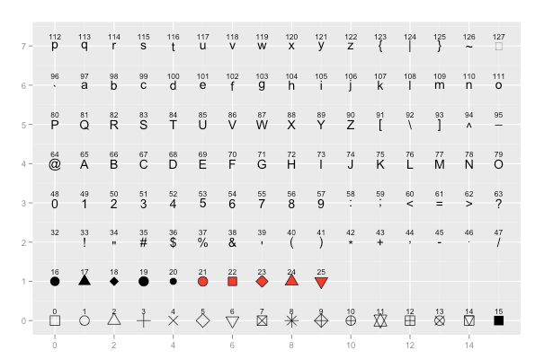

#### Use of shape - 21

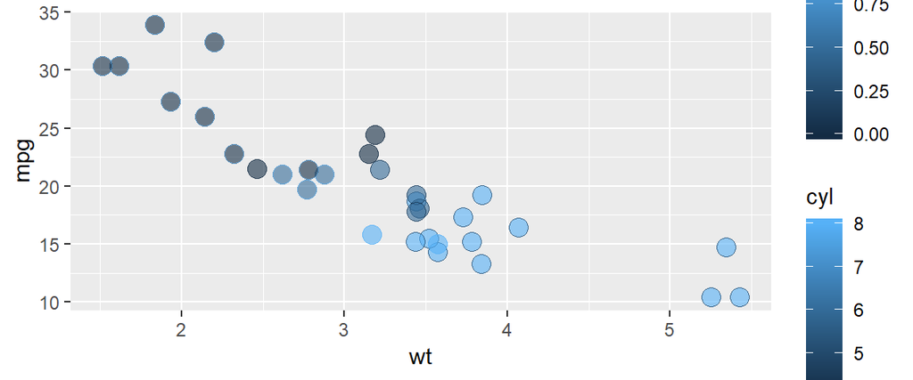

```r
ggplot(mtcars, aes(x = wt, y = mpg, fill=cyl, col = am)) +
  geom_point(shape = 21, size = 4, alpha = 0.6)
```

Note: **label** and **shape** are only applicable to categorical data

Each of the aesthetic that we mapped onto is a scale. We can access these scales with the following functions:

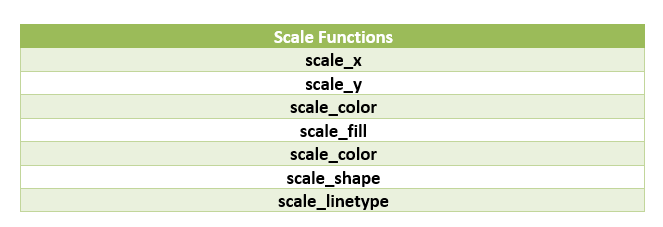

#### To change the axis labels, use **labs()**

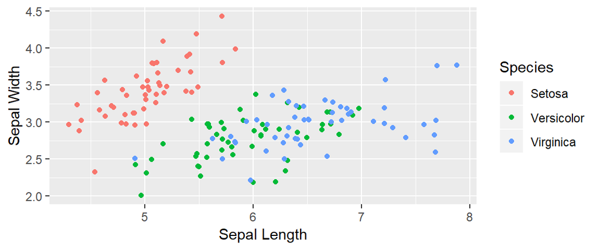

```r
ggplot(iris, aes(Sepal.Length, Sepal.Width, col = Species)) +
  geom_point(position = "jitter") +
  labs(x = "Sepal Length", y = "Sepal Width", col = "Species")
```

#### aes() inside geom_()

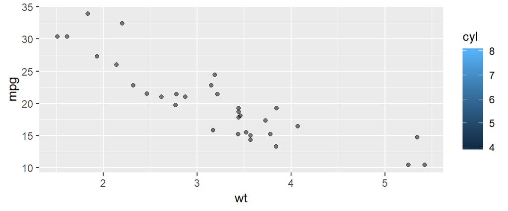

```r
#scatterplot with alpha 0.5
ggplot(mtcars, aes(x = wt, y = mpg, fill = cyl)) + geom_point(alpha= 0.5)
```

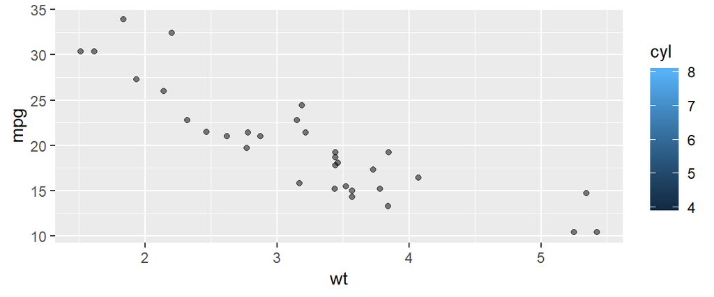

```r
#scatterplot with alpha 0.5
ggplot(mtcars, aes(x = wt, y = mpg)) +
  geom_point(alpha= 0.5, aes(fill = cyl))
```

### Adding layers

#### We can add another data layer with mean to the original mtcars dataset.

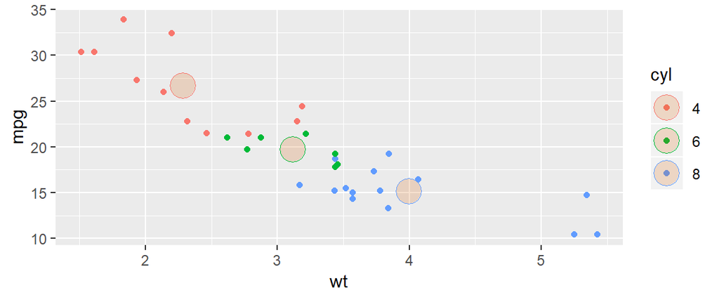

```r
mtcars$cyl = factor(mtcars$cyl)
mtcars_mean = aggregate(mtcars[c(1,3,4,6)], list(mtcars$cyl), mean)
names(mtcars_mean)[1] = "cyl"

ggplot(mtcars, aes(x = wt, y = mpg, col = cyl)) +
  #The below geom_point() inherits data and aesthetics from above ggplot()
  geom_point() +

  geom_point(data = mtcars_mean, shape = 21, size = 7, fill = "#D55E0030")
```

#### Regions with high density

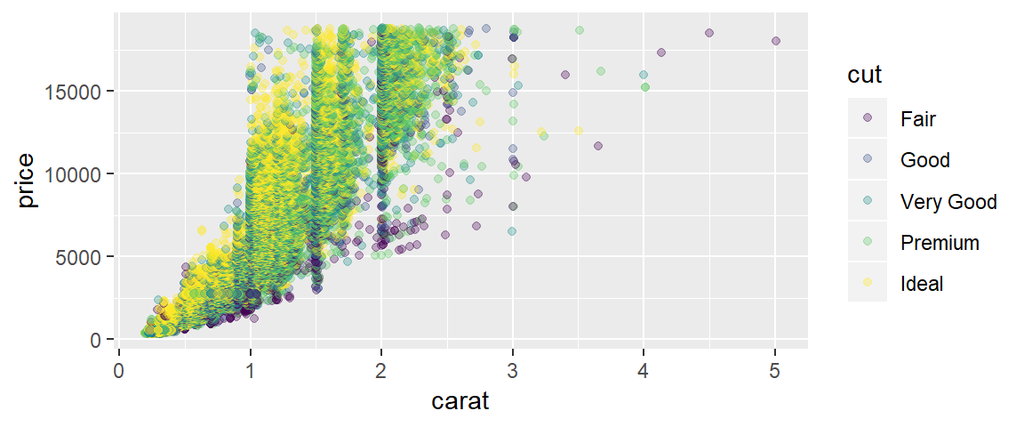

```r
diamonds$cut = factor(diamonds$cut)
ggplot(diamonds, aes(x = carat, y = price, color = cut)) +
  geom_jitter(alpha = 0.3)
```

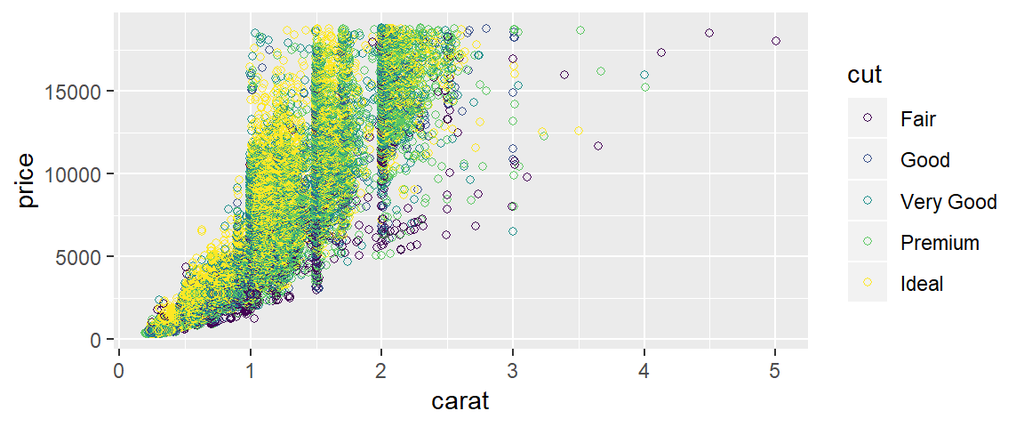

```r
#we can also use hollow circle
ggplot(diamonds, aes(x = carat, y = price, color = cut)) +
  geom_jitter(shape = 1)
```

### Bar plots

#### Histogram (for continuous variable)

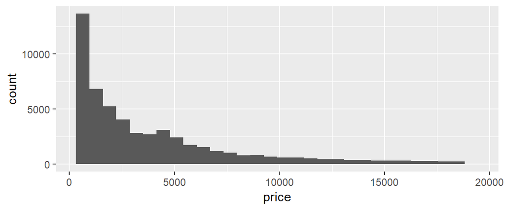

```r
ggplot(diamonds, aes(price)) +
  geom_histogram()
```

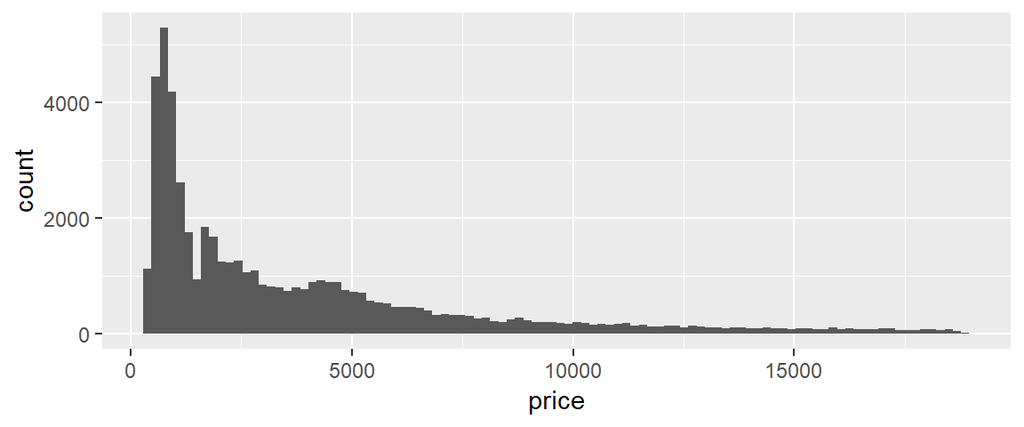

```r
ggplot(diamonds, aes(price)) +
  geom_histogram(bins = 100)
```

#### Histogram of density

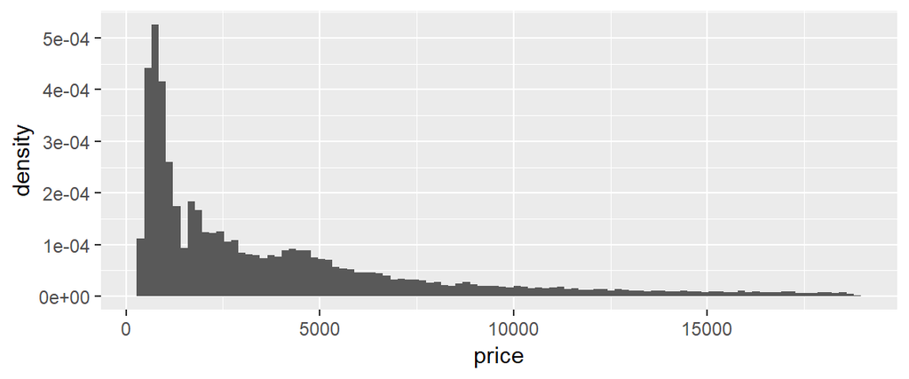

```r
ggplot(diamonds, aes(price)) +
  geom_histogram(aes(y = ..density..), bins = 100)
```

Note that we have used .. before and after density to indicate that this density is stored in an internal dataframe.